# 07 Linear Regression in Supervised Learning

Linear regression is the foundational techniques in supervised learning. It provides a straightforward and often interpretable way of understanding the relationship between dependent and independent variables. With its rich history and mathematical underpinning, linear regression is frequently the first step in many data analysis processes.

# Basic Concept of Linear Regression

Linear regression aims to model the relationship between a dependent variable and one or more independent variables. The goal is to find the line (or hyperplane in multiple dimensions) that best fits the data.

**Advantages**:

- **Fast to train the data**: Because of its matrix algebra connection, linear regression is computationally efficient.
- **Mathematically simple**: The equations behind linear regression are straightforward.
- **Special formulas**: Linear regression boasts unique methods such as LOOCV that hasten computations in machine learning.
- **Theoretical foundation**: Linear regression is one of the most well-developed methods in supervised learning.
- **Interpretability**: The parameters of a linear regression model are easily interpretable, giving insights into the relationships between variables.
- **Statistical inference**: A myriad of tools such as hypothesis tests are available to make statistical inferences.
- **Benchmark model**: Often used as a reference point to compare the performance of other more complex models.

**Disadvantages**:

- **Sensitive to outliers**: Outliers can greatly influence the line of best fit, making predictions less accurate.
- **Data preparation**: The model’s performance is heavily reliant on how well the data is prepared and processed.
- **Overfitting**: With many features, there’s a risk of overfitting the model to the training data.
- **No variable selection**: Without regularization or manual selection, all variables are included in the model.
- **Model formula must be identified**: The user must determine the formula before fitting.

# Assumptions of Linear Regression

For linear regression to be effective and its results reliable, the following assumptions need to be met:

1. **Linearity**: There should be a linear relationship between the independent and dependent variables.
2. **Independence**: Observations should be independent of each other.
3. **Homoscedasticity**: The residuals or errors of prediction should display constant variance.
4. **Normality**: For any given value of x, y should be normally distributed.
5. **No Multicollinearity**: When using multiple linear regression, the independent variables should not exhibit high correlation.

# Simple Linear Regression

For simple linear regression, where there’s just one independent variable, the model is represented as:
$$y =
\beta_0 + \beta_1x + \epsilon$$
Where: * $y$ is the dependent variable. * $x$ is the independent variable. * $\beta_0$ is the intercept. * $\beta_1$ is the coefficient of x. * $\epsilon$ is the error term.

# Multiple Linear Regression

When more than one independent variable is involved, the equation becomes:
$$y = \beta_0 + \beta_1x_1 +
\beta_2x_2 + ... + \beta_px_p + \epsilon$$

## Mathematical formulation

For multiple linear regression, we can represent the problem in matrix form:

$$\mathbf{y} =
\mathbf{X}\boldsymbol{\beta} + \boldsymbol{\epsilon}$$

Where: * $\mathbf{y}$ is a vector of the dependent variable observations. * $\mathbf{X}$ is a matrix of the independent variables (with a column of ones for the intercept). * $\boldsymbol{\beta}$ is a vector of the coefficients. * $\boldsymbol{\epsilon}$ is a vector of the errors.

The solution to find the best coefficients $\boldsymbol{\beta}$ that minimize the sum of squared residuals is:
$$\boldsymbol{\beta} = (\mathbf{X}^T\mathbf{X})^{-1}\mathbf{X}^T\mathbf{y}$$

# Model fitting

The estimated coefficients in linear regression aim to minimize the sum of squared errors. While the matrix formula is mathematically correct, directly using the inverse can cause numerical instability, especially when some of the predictors are collinear. There are more stable algorithms in numerical linear algebra to fit the model, but they are beyond our scope. The matrix formulas above primarily serve to aid understanding and theoretical work.

# Prepare the workspace

```r
options(
  digits = 5,
  scipen = 999,
  warn = -1
)
rm(
  list = ls()
)
library(magrittr)
```

# Load our data

```r
set.seed(
  seed = 823
)
M <- readr::read_csv(
  file = "/Users/thienpham/Data Mining/data/prepared_house_prices.csv",
  col_types = "cnnnnnnnnnnnnnnnnnnnnnnnnnnnnnnnnnnnnnnnnnnnnnnnnnnnnnnnnnnnnnnnnnnnnnnnnnnnnnnnccn",
  name_repair = janitor::make_clean_names
) %>%
  dplyr::filter(train_test == "Train") %>%
  as.data.frame()
M$train_test <- sample(
  x = c("Train","Validation"),
  size = nrow(
    x = M
  ),
  replace = TRUE
)
```

# Fit models

```r
# full model, risks overfitting from too many predictor variables
lm_full <- lm(
  formula = box_cox_sale_price ~ ms_sub_class + ms_zoning + lot_frontage + lot_area + street + alley + lot_shape + land_contour + utilities + lot_config + land_slope + neighborhood + condition1 + condition2 + bldg_type + house_style + overall_qual + overall_cond + year_built + year_remod_add + roof_style + roof_matl + exterior1st + exterior2nd + mas_vnr_type + mas_vnr_area + exter_qual + exter_cond + foundation + bsmt_qual + bsmt_cond + bsmt_exposure + bsmt_fin_type1 + bsmt_fin_sf1 + bsmt_fin_type2 + bsmt_fin_sf2 + bsmt_unf_sf + total_bsmt_sf + heating + heating_qc + central_air + electrical + x1st_flr_sf + x2nd_flr_sf + low_qual_fin_sf + gr_liv_area + bsmt_full_bath + bsmt_half_bath + full_bath + half_bath + bedroom_abv_gr + kitchen_abv_gr + kitchen_qual + tot_rms_abv_grd + functional + fireplaces + fireplace_qu + garage_type + garage_yr_blt + garage_finish + garage_cars + garage_area + garage_qual + garage_cond + paved_drive + wood_deck_sf + open_porch_sf + enclosed_porch + x3ssn_porch + screen_porch + pool_qc + fence + misc_feature + misc_val + mo_sold + yr_sold + sale_type + sale_condition,
  data = M %>% dplyr::filter(
    train_test == "Train" # this is only done on the training data
  )
)
```

Before this video, backwards, forward and stepwise selection was performed at this was the selected predictor variables based on AIC.  
* In a big data situation and we are pressed for time, forward selection will be faster than backwards selection with stepwise somewhere in between. Backwards selection is more complete in that it does a better job at making you dont lose something you wanted to keep.

```r
lm_backward <- lm(
  formula = box_cox_sale_price ~ ms_zoning + lot_area + street + neighborhood +
    condition1 + condition2 + overall_qual + overall_cond + year_remod_add +
    roof_style + exter_qual + foundation + bsmt_cond + bsmt_exposure +
    bsmt_fin_type1 + bsmt_fin_sf1 + bsmt_fin_type2 + bsmt_fin_sf2 +
    bsmt_unf_sf + total_bsmt_sf + heating_qc + central_air +
    gr_liv_area + full_bath + half_bath + kitchen_abv_gr + functional +
    fireplaces + garage_cars + garage_area + garage_qual + garage_cond +
    paved_drive + screen_porch + mo_sold + sale_type + sale_condition,
  data = M %>% dplyr::filter(
    train_test == "Train"
  )
)
lm_forward <- lm(
  formula = box_cox_sale_price ~ ms_sub_class + ms_zoning + lot_frontage +
    lot_area + street + alley + lot_shape + land_contour + utilities +
    lot_config + land_slope + neighborhood + condition1 + condition2 +
    bldg_type + house_style + overall_qual + overall_cond + year_built +
    year_remod_add + roof_style + roof_matl + exterior1st + exterior2nd +
    mas_vnr_type + mas_vnr_area + exter_qual + exter_cond + foundation +
    bsmt_qual + bsmt_cond + bsmt_exposure + bsmt_fin_type1 +
    bsmt_fin_sf1 + bsmt_fin_type2 + bsmt_fin_sf2 + bsmt_unf_sf +
    total_bsmt_sf + heating + heating_qc + central_air + electrical +
    x1st_flr_sf + x2nd_flr_sf + low_qual_fin_sf + gr_liv_area +
    bsmt_full_bath + bsmt_half_bath + full_bath + half_bath +
    bedroom_abv_gr + kitchen_abv_gr + kitchen_qual + tot_rms_abv_grd +
    functional + fireplaces + fireplace_qu + garage_type + garage_yr_blt +
    garage_finish + garage_cars + garage_area + garage_qual +
    garage_cond + paved_drive + wood_deck_sf + open_porch_sf +
    enclosed_porch + x3ssn_porch + screen_porch + pool_qc + fence +
    misc_feature + misc_val + mo_sold + yr_sold + sale_type +
    sale_condition,
  data = M %>% dplyr::filter(
    train_test == "Train"
  )
)
lm_both <- lm(
  formula = box_cox_sale_price ~ ms_zoning + lot_area + street + neighborhood +
    condition1 + condition2 + overall_qual + overall_cond + year_remod_add +
    roof_style + exter_qual + foundation + bsmt_cond + bsmt_exposure +
    bsmt_fin_type1 + bsmt_fin_sf1 + bsmt_fin_type2 + bsmt_fin_sf2 +
    bsmt_unf_sf + total_bsmt_sf + heating_qc + central_air +
    gr_liv_area + full_bath + half_bath + kitchen_abv_gr + functional +
    fireplaces + garage_cars + garage_area + garage_qual + garage_cond +
    paved_drive + screen_porch + mo_sold + sale_type + sale_condition,
  data = M %>% dplyr::filter(
    train_test == "Train"
  )
)
# Now we have 4 models with predicted values and residuals
M <- M %>%
  dplyr::mutate(
    predict_full = predict(object = lm_full,newdata = M),
    predict_backward = predict(object = lm_backward,newdata = M),
    predict_forward = predict(object = lm_forward,newdata = M),
    predict_both = predict(object = lm_both,newdata = M),
    residual_full = predict_full - box_cox_sale_price,
    residual_backward = predict_backward - box_cox_sale_price,
    residual_forward = predict_forward - box_cox_sale_price,
    residual_both = predict_both - box_cox_sale_price
)
```

# Model Evaluation, Diagnostics, and Model Checking

## Metrics:

1. **R-squared**: It signifies the proportion of variance for the dependent variable explained by the independent variables. Looks at the correlation between the predicted value and the actual target value.

```r
M %>%
  dplyr::select(
    train_test,box_cox_sale_price,predict_full,predict_backward,predict_forward,predict_both
  ) %>%
  tidyr::gather(
    key = "model",value = "predict",-train_test,-box_cox_sale_price
  ) %>%
  dplyr::select(train_test,model,box_cox_sale_price,predict) %>%
  dplyr::group_by(train_test,model) %>%
  dplyr::summarise(cor(box_cox_sale_price,predict)) %>%
  tidyr::spread(key = train_test,value = `cor(box_cox_sale_price, predict)`)
```

```
## # A tibble: 4 × 3
##   model            Train Validation
##   <chr>            <dbl>      <dbl>
## 1 predict_backward 0.943      0.930
## 2 predict_both     0.943      0.930
## 3 predict_forward  0.944      0.928
## 4 predict_full     0.944      0.928
```

We want the best values on our validation set. It looks like backward and stepwise are our best models here. Remember to check between our training and validation statistics for overfitting. If the validation stats are better than training then there is overfitting. Here it looks good.

2. **Adjusted R-squared**: R-squared adjusted for the number of predictors in the model.
3. **Mean Squared Error (MSE)**: The average of the squares of the residuals or errors.
   $$MSE =
   \frac{1}{n}\sum_{i=1}^{n} (y_i - \hat{y}_i)^2$$
4. **Root Mean Squared Error (RMSE)**: The square root of MSE. Represents the average error in the same units as y.
   $$RMSE = \sqrt{MSE}$$

```r
M %>%
  dplyr::select(
    train_test,box_cox_sale_price,residual_full,residual_backward,residual_forward,residual_both
  ) %>%
  tidyr::gather(
    key = "model",value = "residual",-train_test,-box_cox_sale_price
  ) %>%
  dplyr::group_by(train_test,model) %>%
  dplyr::summarise(mse = mean(residual^2),mae = mean(abs(residual)),rmse = sqrt(mse))
```

```
## # A tibble: 8 × 5
## # Groups:   train_test [2]
##   train_test model                mse    mae  rmse
##   <chr>      <chr>              <dbl>  <dbl> <dbl>
## 1 Train      residual_backward 0.0195 0.0994 0.140
## 2 Train      residual_both     0.0195 0.0994 0.140
## 3 Train      residual_forward  0.0189 0.0984 0.137
## 4 Train      residual_full     0.0189 0.0984 0.137
## 5 Validation residual_backward 0.0197 0.103  0.140
## 6 Validation residual_both     0.0197 0.103  0.140
## 7 Validation residual_forward  0.0203 0.106  0.143
## 8 Validation residual_full     0.0203 0.106  0.143
```

## Visualizations:

- **Histogram of residuals**: Shows the distribution of residuals.
- **qq-plot of residuals**: Helps in checking the normality of residuals.
- **Scatter plots of the target variable by predicted value**: Checks the model’s linearity assumption.
- **Scatter plots of the target variable by predictors**: Helps visualize relationships and potential outliers.

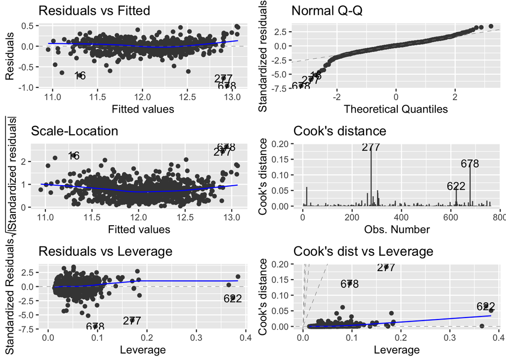

```r
# If we have a linear model in R, the autoplot function gives us 6 default plots to choose from using which = 1:6 and it will always show 3 outliers observations
library(ggfortify)
autoplot(
  object = lm_backward,
  which = 1:6
)
```

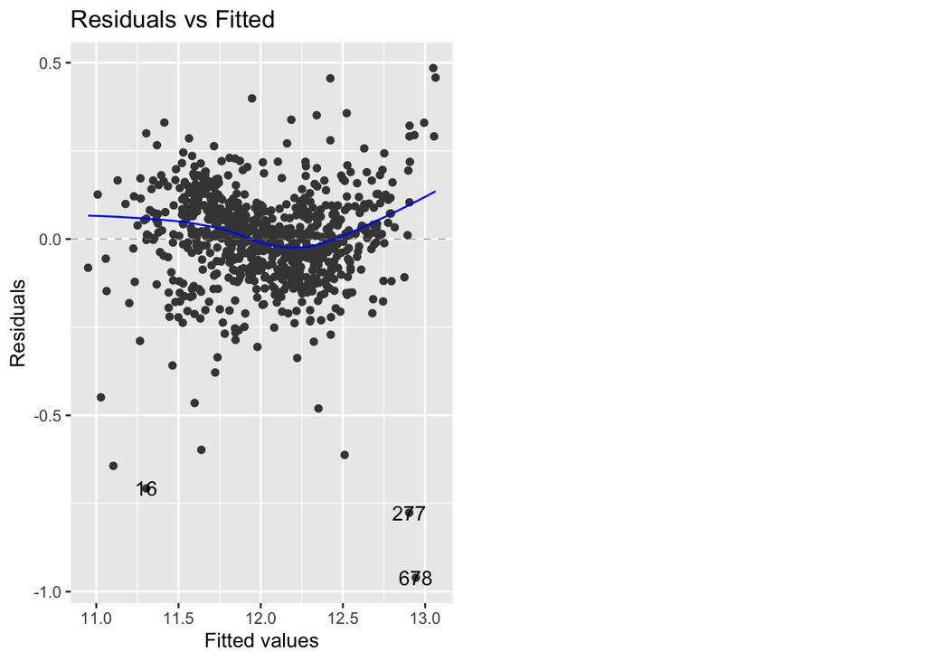

```r
autoplot(
  object = lm_backward,
  which = 1
)
```

For the residuals vs fitted plot, we do not want to see a pattern. A little bending is ok but a clear trend is not accepted and means we would need to adjust our model.

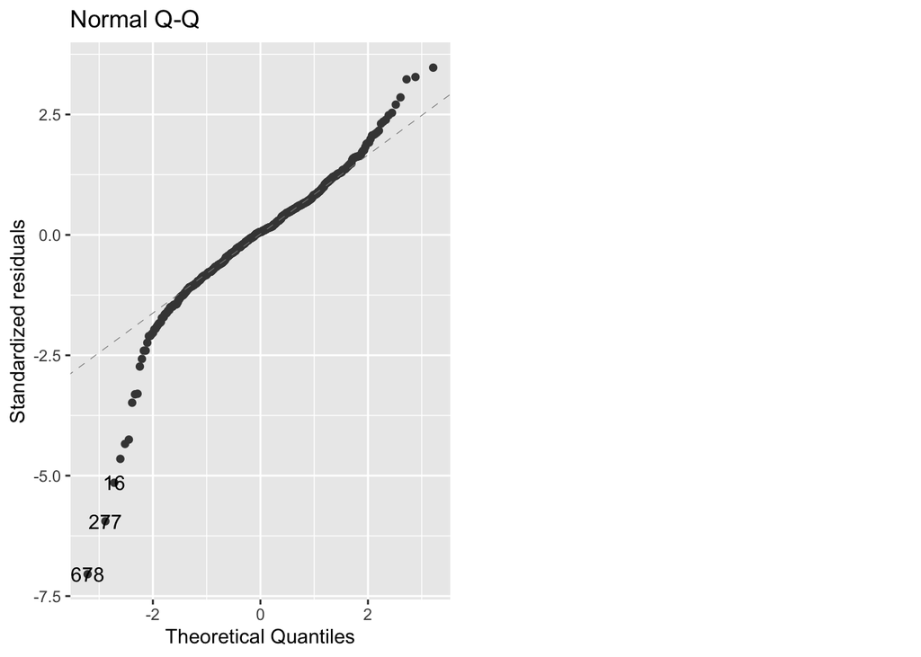

```r
autoplot(
  object = lm_backward,
  which = 2
)
```

For the QQ plot, data along the line indicates normality of residuals. This plot indicates that our data is not normally distributed with heavy tails and outliers present. This is not ideal for hypothesis testing.

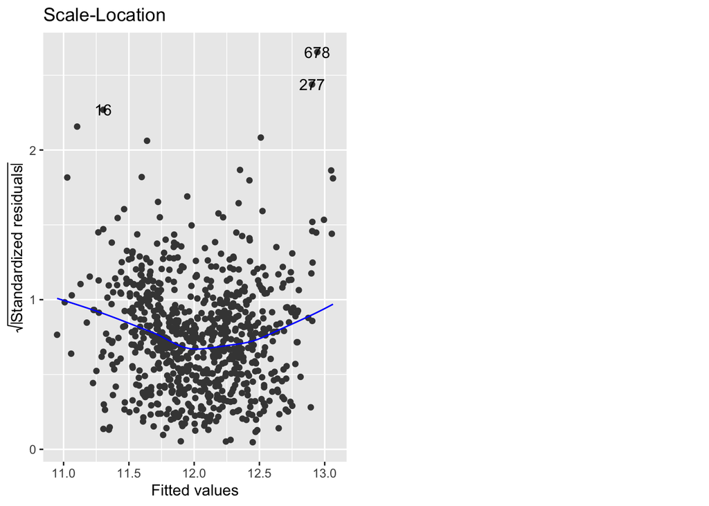

```r
autoplot(
  object = lm_backward,
  which = 3
)
```

Some people prefer this over the first plot. It adjusts and standardizes the resuals and takes sqrt.

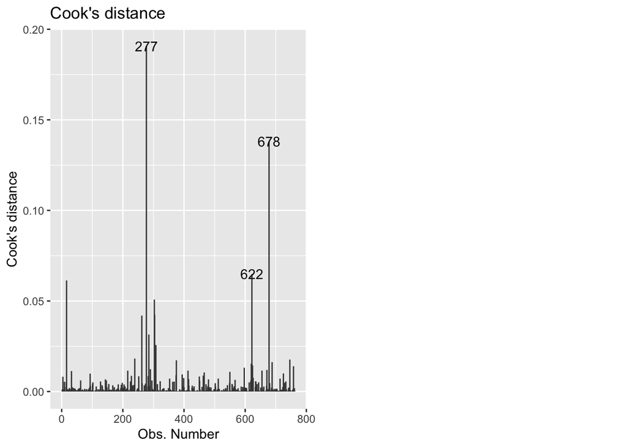

```r
autoplot(
  object = lm_backward,
  which = 4
)
```

Cooks distance shows outliers.

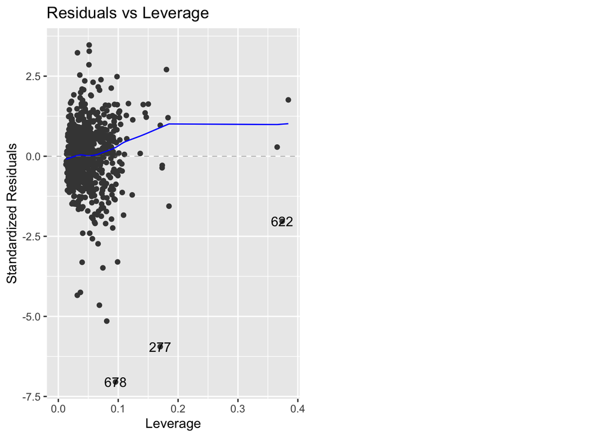

```r
autoplot(
  object = lm_backward,
  which = 5
)
```

Leverage is the amount of influence a data point has on the model. Also a good way to show outliers.

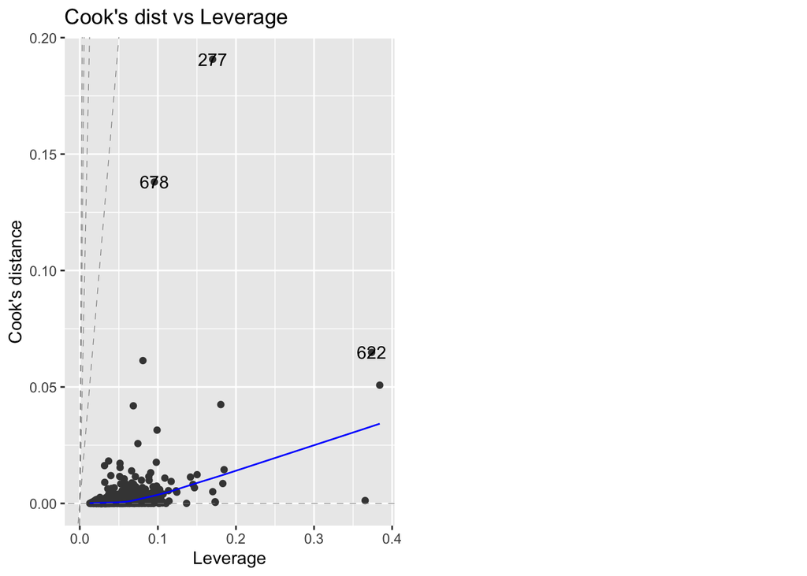

```r
autoplot(
  object = lm_backward,
  which = 6
)
```

Another way to look at leverage with cooks distance.

# Variable Importance

For hypothesis testing. Without the absolute value, it would a t test test statistic. So this is the absolute value of a t test test statistic. A large value will indicate which variable is statistically important. A simple way to measure variable importance in a linear regression model is using:
$$\dfrac{\big|\widehat{\beta_i}\big|}{se\big(\widehat{\beta_i}\big)}$$
Where $\widehat{\beta_i}$ is the estimated coefficient for the variable, and $se\big(\widehat{\beta_i}\big)$ is the standard error of that coefficient.

Variable importance could also be identified by the t and p value. The lower the p value/the higher the t value, the more important

```r
summary(
  object = lm_backward
)
```

```
##
## Call:
## lm(formula = box_cox_sale_price ~ ms_zoning + lot_area + street +
##     neighborhood + condition1 + condition2 + overall_qual + overall_cond +
##     year_remod_add + roof_style + exter_qual + foundation + bsmt_cond +
##     bsmt_exposure + bsmt_fin_type1 + bsmt_fin_sf1 + bsmt_fin_type2 +
##     bsmt_fin_sf2 + bsmt_unf_sf + total_bsmt_sf + heating_qc +
##     central_air + gr_liv_area + full_bath + half_bath + kitchen_abv_gr +
##     functional + fireplaces + garage_cars + garage_area + garage_qual +
##     garage_cond + paved_drive + screen_porch + mo_sold + sale_type +
##     sale_condition, data = M %>% dplyr::filter(train_test ==
##     "Train"))
##
## Residuals:
##     Min      1Q  Median      3Q     Max
## -0.9605 -0.0749  0.0084  0.0807  0.4848
##
## Coefficients:
##                    Estimate   Std. Error t value             Pr(>|t|)
## (Intercept)     5.877627053  0.434819763   13.52 < 0.0000000000000002 ***
## ms_zoning       0.023300131  0.015632595    1.49              0.13653
## lot_area        0.001610555  0.000390110    4.13         0.0000407669 ***
## street          0.151948602  0.085906950    1.77              0.07735 .
## neighborhood    0.070259142  0.016847498    4.17         0.0000341024 ***
## condition1      0.078792488  0.016970690    4.64         0.0000040792 ***
## condition2      0.101629574  0.052042223    1.95              0.05122 .
## overall_qual    0.026571177  0.015807899    1.68              0.09322 .
## overall_cond   -0.036456810  0.013493578   -2.70              0.00706 **
## year_remod_add  0.000001033  0.000000184    5.63         0.0000000265 ***
## roof_style     -0.033144754  0.014133906   -2.35              0.01929 *
## exter_qual      0.062394006  0.017016794    3.67              0.00026 ***
## foundation      0.025262874  0.017297859    1.46              0.14460
## bsmt_cond       0.029134596  0.020847976    1.40              0.16270
## bsmt_exposure  -0.032116525  0.013035491   -2.46              0.01398 *
## bsmt_fin_type1  0.024136601  0.017018374    1.42              0.15654
## bsmt_fin_sf1    0.002788597  0.001660155    1.68              0.09344 .
## bsmt_fin_type2 -0.134565121  0.052686890   -2.55              0.01085 *
## bsmt_fin_sf2   -0.209776144  0.076098147   -2.76              0.00599 **
## bsmt_unf_sf    -0.002079900  0.000696148   -2.99              0.00291 **
## total_bsmt_sf   0.000806890  0.000090958    8.87 < 0.0000000000000002 ***
```

[output cut: 8 more lines]

```
## garage_cars     0.046630980  0.018037357    2.59              0.00993 **
## garage_area     0.000100900  0.000059467    1.70              0.09017 .
## garage_qual    -0.062050049  0.027331895   -2.27              0.02349 *
## garage_cond     0.056941942  0.028885180    1.97              0.04907 *
## paved_drive     0.047206007  0.023784275    1.98              0.04755 *
## screen_porch    0.000163019  0.000101323    1.61              0.10807
## mo_sold         0.004453704  0.001960666    2.27              0.02341 *
## sale_type      -0.048567316  0.021267273   -2.28              0.02268 *
## sale_condition  0.034291901  0.017789305    1.93              0.05429 .
## ---
## Signif. codes:  0 '***' 0.001 '**' 0.01 '*' 0.05 '.' 0.1 ' ' 1
##
## Residual standard error: 0.143 on 725 degrees of freedom
## Multiple R-squared:  0.888,  Adjusted R-squared:  0.883
## F-statistic:  156 on 37 and 725 DF,  p-value: <0.0000000000000002
```

# Extensions to Linear Regression (LASSO, Ridge, Elastic-Net)

- **LASSO**: $\sum_{i=1}^{p} |\beta_i| \leq t$ (Adds L1 regularization)
- **Ridge**: $\sum_{i=1}^{p} \beta_i^2 \leq t$ (Adds L2 regularization)
- **Elastic-Net**: A combination of L1 and L2 regularization.

```r
v_predictors <- c(
  "ms_sub_class","ms_zoning","lot_frontage","lot_area","street","alley","lot_shape","land_contour","utilities","lot_config","land_slope","neighborhood","condition1","condition2","bldg_type","house_style","overall_qual","overall_cond","year_built","year_remod_add","roof_style","roof_matl","exterior1st","exterior2nd","mas_vnr_type","mas_vnr_area","exter_qual","exter_cond","foundation","bsmt_qual","bsmt_cond","bsmt_exposure","bsmt_fin_type1","bsmt_fin_sf1","bsmt_fin_type2","bsmt_fin_sf2","bsmt_unf_sf","total_bsmt_sf","heating","heating_qc","central_air","electrical","x1st_flr_sf","x2nd_flr_sf","low_qual_fin_sf","gr_liv_area","bsmt_full_bath","bsmt_half_bath","full_bath","half_bath","bedroom_abv_gr","kitchen_abv_gr","kitchen_qual","tot_rms_abv_grd","functional","fireplaces","fireplace_qu","garage_type","garage_yr_blt","garage_finish","garage_cars","garage_area","garage_qual","garage_cond","paved_drive","wood_deck_sf","open_porch_sf","enclosed_porch","x3ssn_porch","screen_porch","pool_qc","fence","misc_feature","misc_val","mo_sold","yr_sold","sale_type","sale_condition"
)
cv.glmnet_LASSO <- glmnet::cv.glmnet(
  x = M[,v_predictors] %>% dplyr::filter(M$train_test == "Train") %>% as.matrix(),
  y = M %>% dplyr::filter(M$train_test == "Train") %>% dplyr::select(box_cox_sale_price) %>% unlist(),
  alpha = 1,
  nfolds = 3,
  nlambda=200
)
cv.glmnet_ridge <- glmnet::cv.glmnet(
  x = M[,v_predictors] %>% dplyr::filter(M$train_test == "Train") %>% as.matrix(),
  y = M %>% dplyr::filter(M$train_test == "Train") %>% dplyr::select(box_cox_sale_price) %>% unlist(),
  alpha = 0,
  nfolds = 3,
  nlambda=200
)
cv.glmnet_elasticnet <- glmnet::cv.glmnet(
  x = M[,v_predictors] %>% dplyr::filter(M$train_test == "Train") %>% as.matrix(),
  y = M %>% dplyr::filter(M$train_test == "Train") %>% dplyr::select(box_cox_sale_price) %>% unlist(),
  alpha = 0.5,
  nfolds = 3,
  nlambda=200
)
head(predict(
  object = cv.glmnet_LASSO,
  s = cv.glmnet_LASSO$lambda.min,
  newx = M[,v_predictors] %>% as.matrix()
))
```

```
##          s1
## [1,] 12.270
## [2,] 12.055
## [3,] 12.373
## [4,] 12.106
## [5,] 12.593
## [6,] 11.971
```

```r
head(predict(
  object = cv.glmnet_ridge,
  s = cv.glmnet_LASSO$lambda.min,
  newx = M[,v_predictors] %>% as.matrix()
))
```

```
##          s1
## [1,] 12.283
## [2,] 12.099
## [3,] 12.387
## [4,] 11.992
## [5,] 12.651
## [6,] 12.006
```

```r
head(predict(
  object = cv.glmnet_elasticnet,
  s = cv.glmnet_LASSO$lambda.min,
  newx = M[,v_predictors] %>% as.matrix()
))
```

```
##          s1
## [1,] 12.276
## [2,] 12.055
## [3,] 12.378
## [4,] 12.077
## [5,] 12.613
## [6,] 11.978
```

# Conclusion

Linear regression is a powerful tool with strong theoretical underpinnings that allows for easy interpretability. It’s an essential technique that every data scientist should master. The extensions of linear regression further expand its utility, allowing for more complex relationships to be modeled.

# Homework Problems

1. Choose a dataset of your own and perform a simple linear regression analysis. Interpret the coefficients.
2. Add more predictors to the model from problem 1 and conduct multiple linear regression. How did the R-squared value change?
3. Examine the residuals from the model in problem 2. Check the assumptions of linearity, normality, and homoscedasticity using appropriate plots.
4. Using the model from problem 2, determine the most important predictor variable.
5. Try LASSO and Ridge regression on your dataset. How do the coefficient values change compared to regular linear regression?